# 5. 平滑处理

Natural Language Processing I

5. 平滑处理

WU Xiaokun 吴晓堃

xkun.wu [at] gmail

2022/04/01

# 平滑处理

## 生成未知词汇序列

**平滑处理 smoothing/discounting**

- 从其他（频率更高的）序列匀一部分**概率质量 probability mass**

原始统计直方图

平滑后的直方图

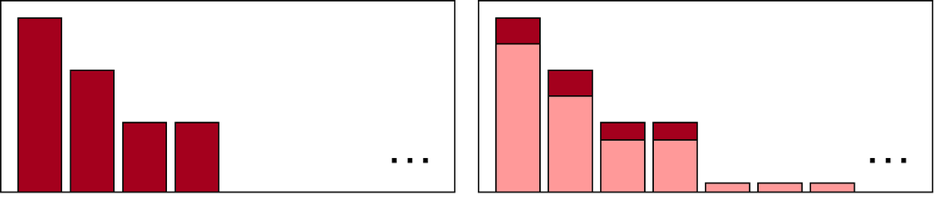

## 加一平滑

也称 **Laplace平滑**：灵感来源于（热）扩散过程

- （假装）每个词汇序列看到过比实际值多一次：所有词计数加一

例如一元语法：$w_i \in w_{1:N}$，序列$W = w_{1:N}$有$N$个词

$$\begin{aligned}
P_{MLE}(w_i) &= \frac{c_i}{N}\\
P_{Add-1}(w_i) &= \frac{c_i + 1}{N + |V|}
\end{aligned}$$

- 注意：分母需要对应增加总共$|V|$个词汇

## 计数折扣

概率质量被转移了多少？

- 从计数的角度看：数值上打了**折扣**

$$\begin{aligned}
\frac{P_{Add-1}(w_i)}{P_{MLE}(w_i)} &= \frac{N}{N + |V|} \frac{(c_i + 1)}{c_i}\\
&= d \frac{c_i + 1}{c_i} = \frac{c_i^\ast}{c_i}
\end{aligned}$$

- **折扣后的计数**：$c_i^\ast = \frac{N}{N + |V|} (c_i + 1) = d (c_i + 1)$；
  - 折扣系数：$d = \frac{N}{N + |V|}$

## 最大似然估计

回顾：**最大似然估计 Maximum Likelihood Estimation (MLE)**

- 使用训练集**估计模型参数**：得到模型
  - 例如二元语法：二元词汇序列的概率
- 模型训练目标：**最大化训练集的可能性**

例如：1万个词的训练集中，“食堂”出现了100次

- MLE 算得“食堂”的概率是$0.01$

MLE **深度绑定到已知信息**，估值很粗糙

- 只能说明：在某个1万词的语料库中，“食堂”最有可能出现100次
- 客观实际未必如此：忽略了先验知识
  - 例如：去眼科医院做统计，估计所有人群的疾病分布

## 实验：二元语法加一平滑

$$\begin{aligned}
P_{MLE}(w_i | w_{i-1}) &= \frac{\Gamma(w_{i-1}, w_i)}{\Gamma(w_{i-1})}\\
P_{Add-1}(w_i | w_{i-1}) &= \frac{\Gamma(w_{i-1}, w_i) + 1}{\Gamma(w_{i-1}) + |V|}
\end{aligned}$$

注意：（下页）计数值变化剧烈

- 加一平滑本质上是**直接修改统计数据**

## 实验：计数折扣比较

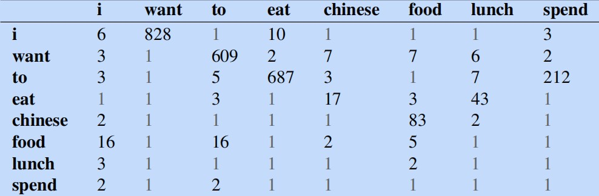

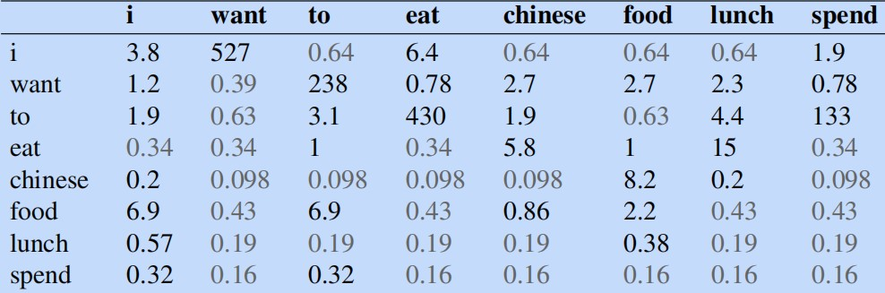

## 加K平滑

注意：每个词的计数只增加一个小数$k$（如0.5）

- **减少概率质量的移动**：让扩散过程变慢
- 计数变化会相应减少：降低修改统计数据的影响

$$\begin{aligned}
P_{Add-k}(w_i | w_{i-1}) &= \frac{\Gamma(w_{i-1}, w_i) + k}{\Gamma(w_{i-1}) + k|V|}
\end{aligned}$$

$k$成为超参数，需要调参

## 简单修改计数小结

方法过于粗糙，只能作为**备选基准**算法

- 并不适合N元语法

但加一平滑常用于其他NLP模型：**有效解决除0问题**

- 文本分类：关键词更重要
- 数据不太稀疏（0的数量不多）时：计数变化不大、修改不明显

# 备选、插值

## 自适应切换方案

回顾：N元模型中的N

**备选法 backoff**：自适应切换到尽可能好的方案

- 如果能预测，就使用三元语法
  - 否则试试二元语法；不行还有一元语法
- 类比：在线流媒体播放器**自动切换**分辨率

**插值法 interpolation**：取三种模型的加权平均

- 通常比备选法性能更好

## 线性插值

简单线性插值：固定权重

$$\begin{aligned}
\hat{P}(w_n|w_{n-2}w_{n-1}) =& \lambda_1 P(w_n)\\
& + \lambda_2 P(w_n|w_{n-1})\\
& + \lambda_3 P(w_n|w_{n-2}w_{n-1})\\
\end{aligned}$$

$$\sum_i \lambda_i = 1$$

权重$\lambda_i$与上下文相关时

$$\begin{aligned}
\hat{P}(w_n|w_{n-2}w_{n-1}) =& \lambda_1(w_{n-2:n-1}) P(w_n)\\
& + \lambda_2(w_{n-2:n-1}) P(w_n|w_{n-1})\\
& + \lambda_3(w_{n-2:n-1}) P(w_n|w_{n-2}w_{n-1})\\
\end{aligned}$$

## 超参数优化

权重$\lambda_i$都是超参数

- 调优参数需要**验证集 validation set**

**Expectation Maximization (EM)** 算法

1. 固定$\lambda_i$，在训练集上**计算**N元语法的概率值
2. 固定N元语法的概率值，在验证集上**优化**$\lambda_i$

$$\log P(w_{1:n}|M(\lambda_1..\lambda_K)) = \sum_i \log P_{M(\lambda_1..\lambda_K)} (w_i | w_{i-1})$$

# Kneser-Ney 平滑处理

## 绝对折扣

回顾折扣：将高频词汇的概率质量**部分转移**到未知词汇

- 问题：如何确定计数折扣值？

[Church 1991] 训练、验证集中**二元词对计数**比较

| 训练 | 0 | 1 | 2 | 3 | 4 | 5 | 6 | 7 | 8 | 9 |
| --- | --- | --- | --- | --- | --- | --- | --- | --- | --- | --- |
| 验证 | $2.7e^{-5}$ | 0.448 | 1.25 | 2.24 | 3.23 | 4.21 | 5.23 | 6.21 | 7.21 | 8.26 |

$$\begin{aligned}
P_{AbsoluteDiscounting}(w_i | w_{i-1}) &= \frac{\Gamma(w_{i-1}, w_i) - d}{\Gamma(w_{i-1})} + \lambda(w_{i-1}) P(w_i)
\end{aligned}$$

根据数据统计：**固定计数折扣**值$d=0.75$

- 也可在计数为1时，令$d=0.5$

思考：折扣后成负数了怎么办？

## 一元概率

基于**通用词频**的模型性能通常较差，特别是一元语法

```
他下课后去了_
```

- “马克思”的词频远高于“食堂”
  - [Google Books Ngram Viewer](https://books.google.com/ngrams/graph?content=%E9%A3%9F%E5%A0%82%2C%E9%A9%AC%E5%85%8B%E6%80%9D&year_start=1900&year_end=2019&corpus=34&smoothing=3)
- 但“马克思”通常跟“主义”**连用**

不应该简单计算“马克思”出现的概率

- 而是计算“马克思”和一个**新词搭配的可能性**

## Kneser-Ney

[Kneser and Ney 1995] 词的概率与同时出现的**上下文种类**正相关

- 等价于：二元词汇序列的种类
- 计算：每个二元词汇序列**第一次出现**时，计数加一

$$P_{cont}(w) \propto |{v : \Gamma(vw) > 0}|$$

合理性：如果一个词在很多不同的上下文都出现过，

- 那么这个词也更有可能在新的上下文再次出现。
  - 这个词可以认为是“**胶水词**”：非常容易与其他词连接

## Kneser-Ney 概率

首先表述**正相关性**：含$v$的二元词汇序列的种类

$$P_{cont}(w) \propto |{v : \Gamma(vw) > 0}|$$

其次，计算概率需要**归一化**

- 二元词汇序列的总数

$$|{(u',w') : \Gamma(u'w') > 0}|$$

- 归一化得到概率值

$$P_{cont}(w) = \frac{|{v : \Gamma(vw) > 0}|}{|{(u',w') : \Gamma(u'w') > 0}|}$$

## Kneser-Ney 插值

**绝对折扣**与**上下文计数**的线性组合

$$\begin{aligned}
P_{KN}(w_i | w_{i-1}) &= \frac{\max\{\Gamma(w_{i-1}, w_i) - d, 0\}}{\Gamma(w_{i-1})} + \lambda(w_{i-1}) P_{cont}(w_i)
\end{aligned}$$

- 注意分子：折扣成负数时要裁剪为0
- $\lambda$ 是**正则化常量**

$$\begin{aligned}
\lambda(w_{i-1}) = \frac{d}{\sum_v \Gamma(w_{i-i}v)} |\{w : \Gamma(w_{i-1}w) > 0\}|
\end{aligned}$$